# BellaBeat - Data Analysis

Aidan Wilson

2022-09-17

[figure not shown]

# BellaBeat - Data Analysis Capstone project

## By Aidan Wilson

Ask Prepare Process Analyze Share Act

### Characters and products

- Urška Sršen: Bellabeat’s cofounder and Chief Creative Officer
- Sando Mur: Mathematician and Bellabeat’s cofounder; key member of the Bellabeat executive team
- Bellabeat marketing analytics team: A team of data analysts responsible for collecting, analyzing, and reporting data that helps guide Bellabeat’s marketing strategy. You joined this team six months ago and have been busy learning about Bellabeat’’s mission and business goals — as well as how you, as a junior data analyst, can help Bellabeat achieve them.

### Product

- Bellabeat app: The Bellabeat app provides users with health data related to their
  - activity,
  - sleep,
  - stress,
  - menstrual cycle,
  - mindfulness habits. This data can help users better understand their current habits and make healthy decisions. The Bellabeat app connects to their line of smart wellness products.
- Leaf: Bellabeat’s classic wellness tracker can be worn as a bracelet, necklace, or clip. The Leaf tracker connects to the Bellabeat app to track activity, sleep, and stress.
- Time: This wellness watch combines the timeless look of a classic timepiece with smart technology to track user:
  - activity
  - sleep
  - stress The Time watch connects to the Bellabeat app to provide you with insights into your daily wellness.
- Spring: This is a water bottle that tracks daily water intake using smart technology to ensure that you are appropriately hydrated throughout the day. The Spring bottle connects to the Bellabeat app to track your hydration levels.
- Bellabeat membership: Bellabeat also offers a subscription-based membership program for users. Membership gives users 24/7 access to fully personalized guidance on nutrition, activity, sleep, health and beauty, and mindfulness based on their lifestyle and goals.

# Ask

Sršen asks you to analyze smart device usage data in order to gain insight into how consumers use non-Bellabeat smart devices. She then wants you to select one Bellabeat product to apply these insights to in your presentation. These questions will guide your analysis:

1. What are some trends in smart device usage?
2. How could these trends apply to Bellabeat customers?
3. How could these trends help influence Bellabeat marketing strategy?

# Deliverables

1. A clear summary of the business task
2. A description of all data sources used
3. Documentation of any cleaning or manipulation of data
4. A summary of your analysis
5. Supporting visualizations and key findings 6.Your top high-level content recommendations based on your analysis

# Ask Challange:

Clear Statement of the business task: *“BellaBeat would like to see insights into their smart devices, with this capstone focusing on one device. The data and graphics should help convey their clientels current purchasing and living habits and recommend BellaBeats next steps in marketing.”*

Key stakeholders:

- Urška Sršen: Co-founder and CCO
- Sando Mur: BellaBeat exuctive team member
- Marketing team

# Prepare

Look into the fitbit dataset

| x |
| --- |
| dailyActivity_merged.csv |
| dailyCalories_merged.csv |
| dailyIntensities_merged.csv |
| dailySteps_merged.csv |
| heartrate_seconds_merged.csv |
| hourlyCalories_merged.csv |
| hourlyIntensities_merged.csv |
| hourlySteps_merged.csv |
| minuteCaloriesNarrow_merged.csv |
| minuteCaloriesWide_merged.csv |
| minuteIntensitiesNarrow_merged.csv |
| minuteIntensitiesWide_merged.csv |
| minuteMETsNarrow_merged.csv |
| minuteSleep_merged.csv |
| minuteStepsNarrow_merged.csv |
| minuteStepsWide_merged.csv |
| sleepDay_merged.csv |
| weightLogInfo_merged.csv |

Now that I have looked into the Data sets provided, based on what datasets exist. I will choose to use the sleeping patterns data set.

I chose this as it posed the following issues:

- Dealing with time and dates
- Showing issues with lack of units being present

Now to clean up the data

Taking the *“Sleep Data”* into account, I have separated the date and time into two different columns and changed the minutes to hours. Luckily, there was not much cleaning required for this work.

Now that we have the data in a better orientation and legible formats we can plot some graphs.

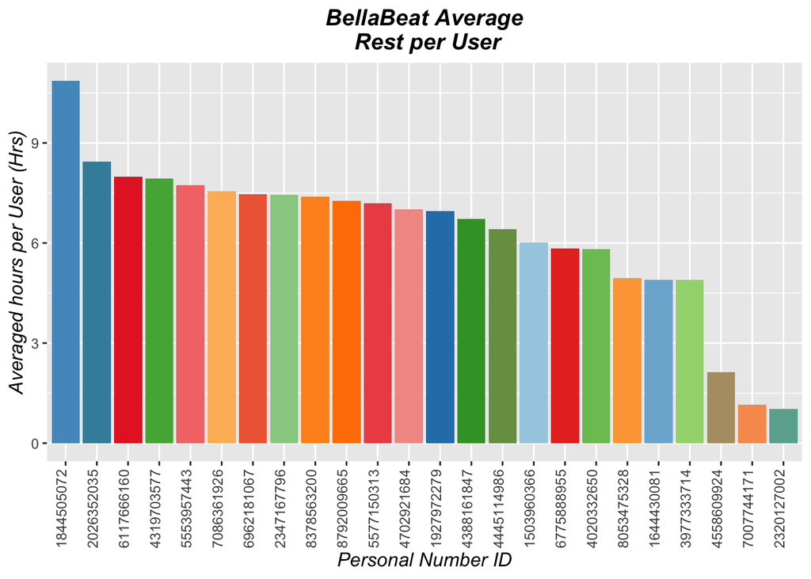

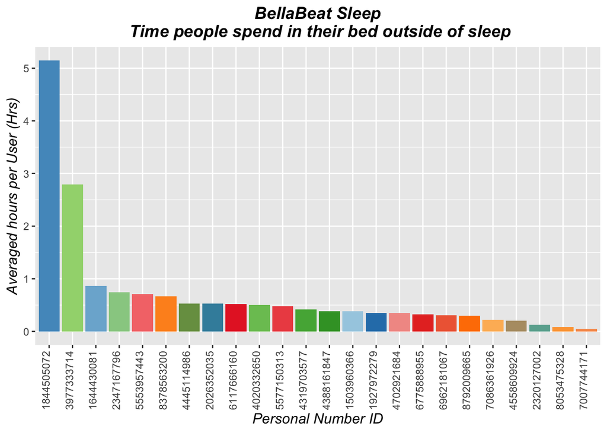

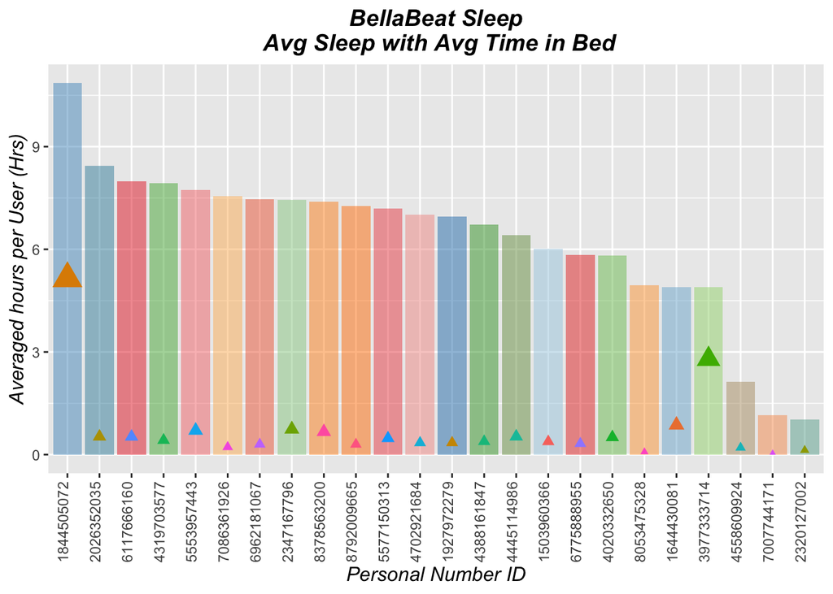